# Statistical Inference Project

# Part 1 - Exponential Distribution Simulation

We simulate the exponential distribution drawing 40 samples each time and getting the mean and lambda = 0.2 for 1000 times.

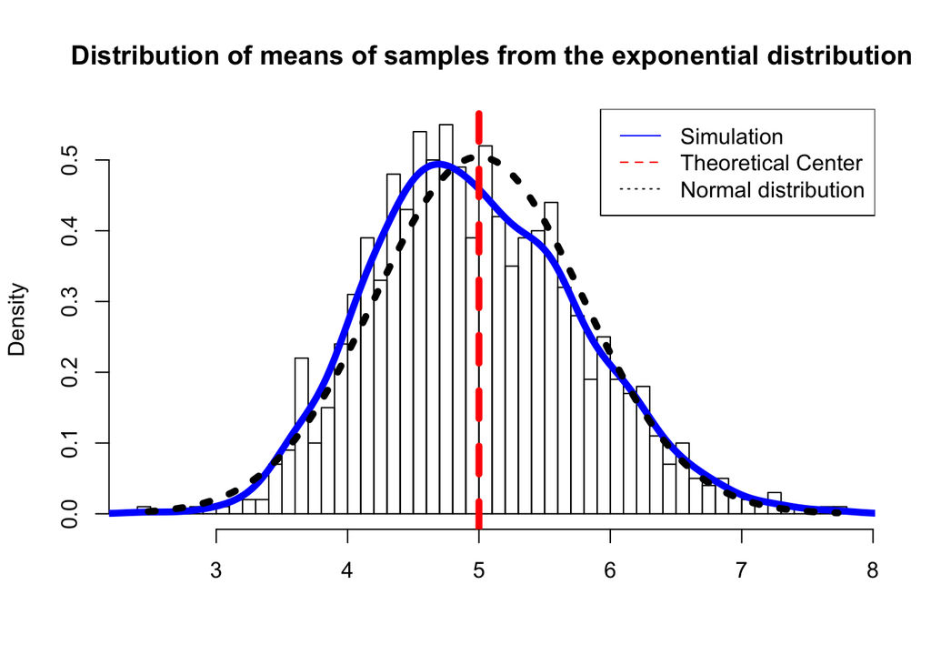

```r
set.seed(1001)
lambda <- 0.2
num_of_sims <- 1000
sample_size <- 40
mns = NULL
# Means of means
for(i in 1 : num_of_sims) mns = c(mns, mean(rexp(sample_size, rate = lambda)))
hist(mns, breaks = 50, prob = TRUE, main = "Distribution of means of samples from the exponential distribution", xlab = "")
# density of the means of samples
lines(density(mns), col = "blue", lty = 1, lwd = 5)
# Theoretical mean of distribution
abline(v=1/lambda, col="red", lty=2, lwd = 5)
x <- seq(min(mns), max(mns), length=100)
y <- dnorm(x, mean=1/lambda, sd=(1/lambda/sqrt(sample_size)))
# Normal distribution
lines(x, y, pch=22, col="black", lty=3, lwd = 5)
legend('topright', c("Simulation", "Theoretical Center", "Normal distribution"), lty=c(1,2,3), col=c("blue", "red","black"))
```

As we can see the sample means is centered at 4.9737652, the theoretical center of the distribution is $\frac{1}{\lambda}$ = 5, the variance of sample means is 0.6220001 where the theoretical variance of the distribution is $\frac{\sigma^2}{n} = \frac{1}{\lambda^2\cdot n} = \frac{1}{0.04 \cdot 40}$ = 0.625.

We draw a q-q plot to show normality:

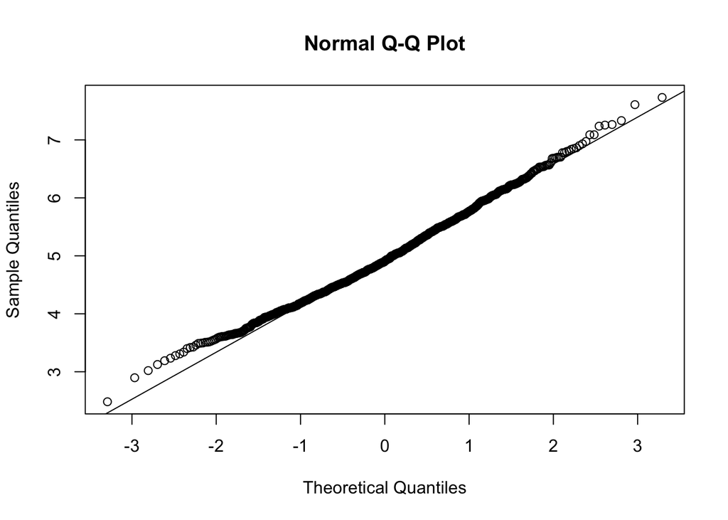

```r
qqnorm(mns); qqline(mns)
```

Now we will compute the confidence interval: Finally, let’s evaluate the coverage of the confidence interval for $1/\lambda = \bar{X} \pm 1.96 \frac{S}{\sqrt{n}}$

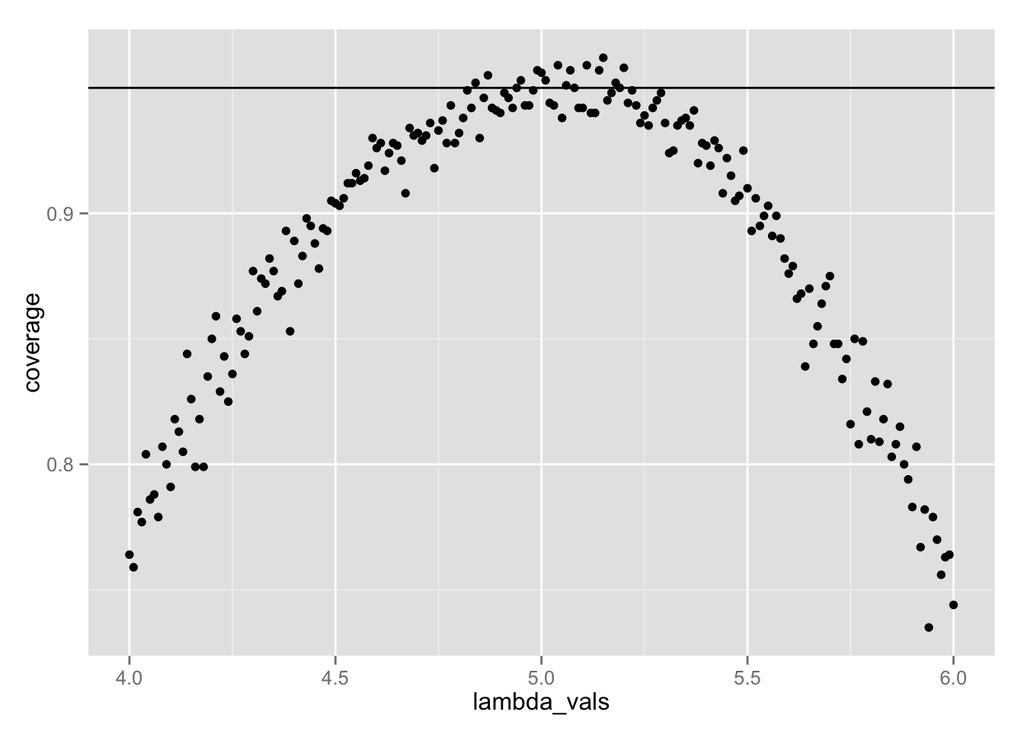

# Part 2 - Inferential Statistics for Tooth Growth Dataset

## Overview

In this section we analyze the `TootGrowth` dataset which describes the effect of vitamin C on tooth growth in guinea pigs

The `ToothGrowth` dataset consists of 60 observations of 3 variables:

- `len`: Tooth length in millimeters (numeric variable)
- `supp`: Supplement type (factor variable with levels VC and OJ)
- `dose`: Dose in milligrams (numeric variable)

Even though `dose` is a numeric variable we will treat it as a factor in the subsequent analysis because only three dose levels of Vitamin C (0.5, 1, and 2 mg) were used.

Here’s the structure and summary of the dataset:

```r
str(ToothGrowth)
```

```
## 'data.frame':    60 obs. of  3 variables:
##  $ len : num  4.2 11.5 7.3 5.8 6.4 10 11.2 11.2 5.2 7 ...
##  $ supp: Factor w/ 2 levels "OJ","VC": 2 2 2 2 2 2 2 2 2 2 ...
##  $ dose: num  0.5 0.5 0.5 0.5 0.5 0.5 0.5 0.5 0.5 0.5 ...
```

```r
summary(ToothGrowth)
```

```
##       len        supp         dose
##  Min.   : 4.20   OJ:30   Min.   :0.500
##  1st Qu.:13.07   VC:30   1st Qu.:0.500
##  Median :19.25           Median :1.000
##  Mean   :18.81           Mean   :1.167
##  3rd Qu.:25.27           3rd Qu.:2.000
##  Max.   :33.90           Max.   :2.000
```

Also how many pigs were assigned to each dose (10 for each):

```
##      supp
## dose  OJ VC
##   0.5 10 10
##   1   10 10
##   2   10 10
```

## Exploratory Data Analysis (EDA)

We treat the dose as a factor since there are only 3 values. We use ggplot to make some plots to explore the relationships between tooth length and supplement and tooth length and dose:

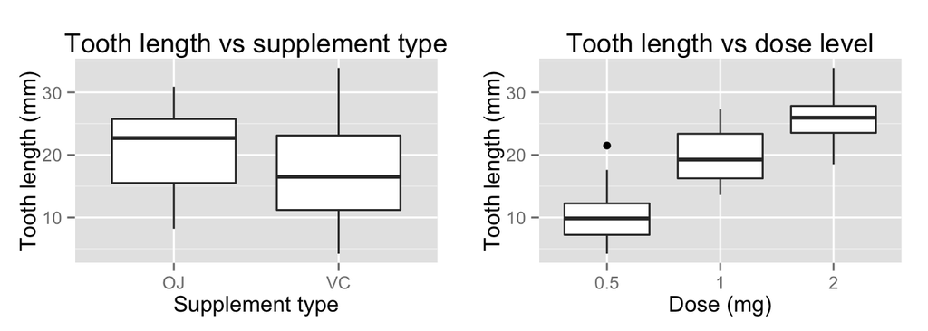

The right boxplot suggests that the dose makes significant differences in tooth growth. Their interquartile ranges between doses do not even overlap as shown also numerically in the following table:

```r
ToothGrowth %>% group_by(dose) %>%
  summarize(
    quantile_25 = quantile(len, 0.25),
    quantile_75 = quantile(len, 0.75)
  )
```

```
## Source: local data frame [3 x 3]
##
##   dose quantile_25 quantile_75
## 1  0.5       7.225      12.250
## 2  1.0      16.250      23.375
## 3  2.0      23.525      27.825
```

## Hypothesis tests

### Assumptions

We have $n \le 30$ so we will use the t distribution for our hypothesis tests and when constructing confidence intervals.

We assume that

1. The observations are independent
2. Pigs are sampled from a nearly normal distribution.

### Differences in supplement types

First, we will check if the observed difference in tooth length means between pigs who received their dose using orange juice and those who received their dose via ascorbic acid is statistically different from 0.

Our conservative choice will be a t-test with unequal variances of the two samples. The table below shows the results:

```
##   estimate estimate1 estimate2 statistic    p.value parameter   conf.low
## 1      3.7  20.66333  16.96333  1.915268 0.06063451  55.30943 -0.1710156
##   conf.high
## 1  7.571016
```

p-value is 0.061 , larger than 0.05, so we do not reject the null hypothesis. The confidence interval is -0.171, 7.571 and it includes 0.

### Differences in dose levels

We are dealing with 3 different dose levels, so we apply 3 t-tests to cover all factor level combinations. The null hypothesis in all cases is that the average difference in tooth length is 0.

We show the three 3 pairwise comparisons. `null_hypothesis` shows which null hypothesis was used for the respective t-test

```r
pairwise_results <- t.test(ToothGrowth$len[ToothGrowth$dose == 2],
       ToothGrowth$len[ToothGrowth$dose == 1]) %>%
  tidy %>%
  mutate(
    null_hypothesis = 'µ2mg - µ1mg = 0'
  ) %>%
  select(9, 1:8)


pairwise_results <- t.test(ToothGrowth$len[ToothGrowth$dose == 2],
       ToothGrowth$len[ToothGrowth$dose == 0.5]) %>%
  tidy %>%
  mutate(
    null_hypothesis = 'µ2mg - µ0.5mg = 0'
  ) %>%
  select(9, 1:8) %>%
  bind_rows(pairwise_results, .)

pairwise_results <- t.test(ToothGrowth$len[ToothGrowth$dose == 1],
       ToothGrowth$len[ToothGrowth$dose == 0.5]) %>%
  tidy %>%
  mutate(
    null_hypothesis = 'µ1mg - µ0.5mg = 0'
  ) %>%
  select(9, 1:8) %>%
  bind_rows(pairwise_results, .)

print.data.frame(pairwise_results)
```

```
##     null_hypothesis estimate estimate1 estimate2 statistic      p.value
## 1   µ2mg - µ1mg = 0    6.365    26.100    19.735  4.900484 1.906430e-05
## 2 µ2mg - µ0.5mg = 0   15.495    26.100    10.605 11.799046 4.397525e-14
## 3 µ1mg - µ0.5mg = 0    9.130    19.735    10.605  6.476648 1.268301e-07
##   parameter  conf.low conf.high
## 1  37.10109  3.733519  8.996481
## 2  36.88259 12.833833 18.156167
## 3  37.98641  6.276219 11.983781
```

In all these cases the p-value is much smaller than 0.05 so we reject the null hypothesis for all cases.

Interpreting the first row of the table for illustriation:

We can say at least with a confidence level of 95% that the average tooth length of guinea pigs who received a 2mg dose of vitamin C is on average 3.73 to 9 millimeters higher than those who received a 1mg dose.

# Conclusions

We showed that doses make significant differences in tooth growth. But we are not sure about the effect of supplement types on tooth growth. As future work, the combination of doses and supplements could be studied.